# Collaborative Portion

Bernard Fay; Github: bj99fay; Chase Weida; Github: cweida

2/5/2020

#### 1. Overall number of chocolate bars?

```r
length(choco$Rating)
```

```
## [1] 1852
```

There are 1852 unique chocolate bars tested and rated.

#### 2. How does the number of ratings depend on the year?

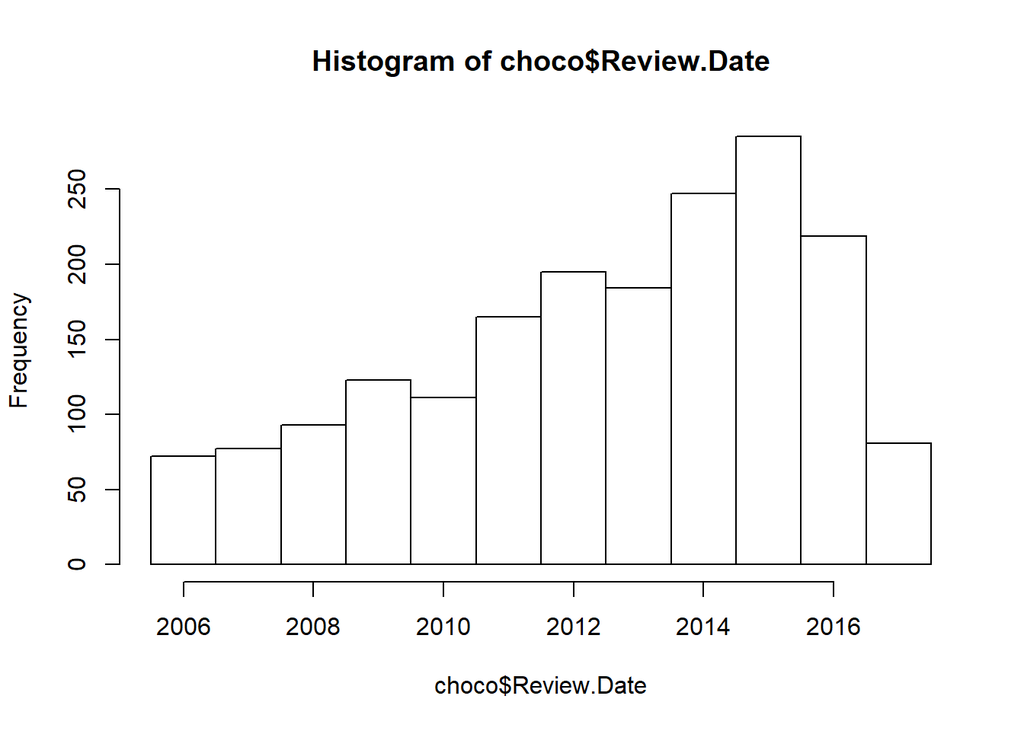

```r
hist(choco$Review.Date, breaks = seq(2005.5, 2017.5, by = 1))
```

As you can see, that the ratings slowly increased over the years until 2015, but fell a bit in 2016 and much more greatly in 2017.

#### 3. What are the three locations with the most ratings? How do ratings compare across these company locations?

```r
tbl <- table(choco$Company.Location)
df <- tbl[order(-as.numeric(tbl))]
df[1:3]
```

```
##
## U.S.A. France Canada
##    787    158    132
```

```r
US <- choco[choco$Company.Location == "U.S.A.", ]
USmean <- mean(US[,"Rating"])
names(USmean) <- "U.S.A. mean"

France <- choco[choco$Company.Location == "France", ]
FranceMean <- mean(France[,"Rating"])
names(FranceMean) <- "France mean"

Canada <- choco[choco$Company.Location == "Canada", ]
CanadaMean <- mean(Canada[,"Rating"])
names(CanadaMean) <- "Canada mean"

c(USmean, FranceMean, CanadaMean)
```

```
## U.S.A. mean France mean Canada mean
##    3.162325    3.253165    3.312500
```

The USA, France, and Canada have the most ratings. Surprisingly, the ratings go in the reverse order with Canada at the top followed by France and the USA.

#### 4. Ask an interesting question.

Do ratings depend on company location?

#### 5. Answer the question you came up with in question 4

```r
df <- choco[, c("Company.Location", "Rating")]
head(df)
```

```
##   Company.Location Rating
## 1           France   3.75
## 2           France   2.75
## 3           France   2.75
## 4           France   3.00
## 5           France   3.25
## 6           France   3.75
```

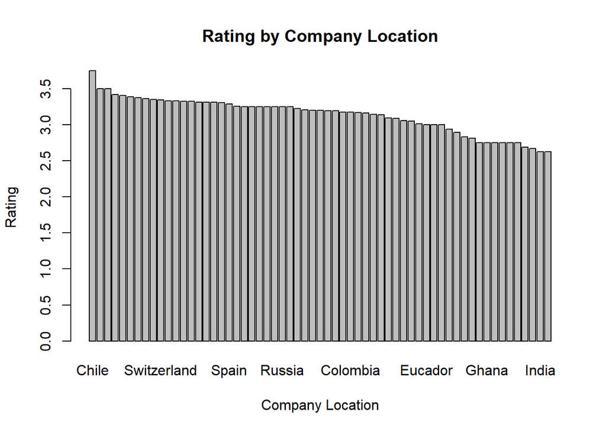

```r
df2 <- aggregate(df[, 2], list(df$Company.Location), mean)
names(df2)[names(df2) == "Group.1"] <- "Company.Location"
names(df2)[names(df2) == "x"] <- "Rating"
df2 <- df2[order(-df2$Rating),]
barplot(df2$Rating, main='Rating by Company Location', ylab='Rating', xlab='Company Location', names.arg=df2$Company.Location)
```

#### 6. Describe the workflow.

To complete this portion of the lab we divided it up and worked on it when we each had time. Chase worked on questions 1 thorugh 3 and Bernie worked on questions 3 through 6. This worked well, especially when working at separate times.